# Data Processing

## Objective:

Create a prediction model that will predict whether a passenger on the titanic would have been survived or not.

## Data Dictionary

survival - Survival (0 = No; 1 = Yes)

pclass - Passenger Class (1 = 1st; 2 = 2nd; 3 = 3rd)

name - Name of passenger

sex - Sex

age - Age

sibsp - Number of Siblings/Spouses Aboard

parch - Number of Parents/Children Aboard

ticket - Ticket Number

fare - Passenger Fare (british pound)

cabin - Cabin

embarked - Port of Embarkation (C = Cherbourg; Q = Queenstown; S = Southampton)

## Load csv file

```python
# install and import necessary libraries
import pandas as pd
import numpy as np
import matplotlib.pyplot as plt
import seaborn as sns
```

```python
# Load titanic_passenger_list.csv into dataframe
df = pd.read_csv("titanic_passenger_list.csv")
```

## Data Overview

```python
# view the first 10 rows of the dataframe
df.head(10)
```

|  | pclass | survived | name | sex | age | sibsp | parch | ticket | fare | cabin | embarked |
| --- | --- | --- | --- | --- | --- | --- | --- | --- | --- | --- | --- |
| 0 | 1 | 1 | Allen, Miss. Elisabeth Walton | female | 29.00 | 0 | 0 | 24160 | 211.3375 | B5 | S |
| 1 | 1 | 1 | Allison, Master. Hudson Trevor | male | 0.92 | 1 | 2 | 113781 | 151.5500 | C22 C26 | S |
| 2 | 1 | 1 | Allison, Master. Hudson Trevor | male | 0.92 | 1 | 2 | 113781 | 151.5500 | C22 C26 | S |
| 3 | 1 | 0 | Allison, Miss. Helen Loraine | female | 2.00 | 1 | 2 | 113781 | 151.5500 | C22 C26 | S |
| 4 | 1 | 0 | Allison, Mr. Hudson Joshua Creighton | male | 30.00 | 1 | 2 | 113781 | 151.5500 | C22 C26 | S |
| 5 | 1 | 0 | Allison, Mrs. Hudson J C (Bessie Waldo Daniels) | fe male | 25.00 | 1 | 2 | 113781 | 151.5500 | C22 C26 | S |
| 6 | 1 | 1 | Anderson, Mr. Harry | male | 48.00 | 0 | 0 | 19952 | 26.5500 | E12 | S |
| 7 | 1 | 1 | Andrews, Miss. Kornelia Theodosia | female | 63.00 | 1 | 0 | 13502 | 77.9583 | D7 | S |
| 8 | 1 | 0 | Andrews, Mr. Thomas Jr | male | 39.00 | 0 | 0 | 112050 | 0.0000 | A36 | S |
| 9 | 1 | 1 | Appleton, Mrs. Edward Dale (Charlotte Lamson) | female | 53.00 | 2 | 0 | 11769 | 51.4792 | C101 | S |

```python
# view a 10 row sample of the dataframe
df.sample(10)
```

|  | pclass | survived | name | sex | age | sibsp | parch | ticket | fare | cabin | embarked |
| --- | --- | --- | --- | --- | --- | --- | --- | --- | --- | --- | --- |
| 83 | 1 | 1 | Crosby, Miss. Harriet R | female | 36.0 | 0 | 2 | WE/P 5735 | 71.0000 | B22 | S |
| 930 | 3 | 0 | Kiernan, Mr. John | male | NaN | 1 | 0 | 367227 | 7.7500 | NaN | Q |
| 1230 | 3 | 0 | Strilic, Mr. Ivan | male | 27.0 | 0 | 0 | 315083 | 8.6625 | NaN | S |
| 1071 | 3 | 0 | O'Brien, Mr. Timothy | male | NaN | 0 | 0 | 330979 | 7.8292 | NaN | Q |
| 1098 | 3 | 0 | Palsson, Master. Paul Folke | male | 6.0 | 3 | 1 | 349909 | 21.0750 | NaN | S |
| 878 | 3 | 0 | Ilmakangas, Miss. Ida Livija | female | 27.0 | 1 | 0 | STON/O2. 3101270 | 7.9250 | NaN | S |
| 164 | 1 | 1 | Holverson, Mrs. Alexander Oskar (Mary Aline To... | female | 35.0 | 1 | 0 | 113789 | 52.0000 | NaN | S |
| 323 | 1 | 1 | Young, Miss. Marie Grice | female | 36.0 | 0 | 0 | PC 17760 | 135.6333 | C32 | C |
| 1186 | 3 | 0 | Samaan, Mr. Hanna | male | NaN | 2 | 0 | 2662 | 21.6792 | NaN | C |
| 840 | 3 | 0 | Gustafsson, Mr. Karl Gideon | male | 19.0 | 0 | 0 | 347069 | 7.7750 | NaN | S |

```python
# use shapeto determine how many rows and columns are in the dataframe
df.shape
```

```
(1310, 11)
```

```python
# Check for duplicate values in the data
df.duplicated().sum()
```

```
1
```

```python
# information of all columns in the dataframe
df.info()
```

```
<class 'pandas.core.frame.DataFrame'>
RangeIndex: 1310 entries, 0 to 1309
Data columns (total 11 columns):
 #   Column    Non-Null Count  Dtype
---  ------    --------------  -----
 0   pclass    1310 non-null   int64
 1   survived  1310 non-null   int64
 2   name      1310 non-null   object
 3   sex       1310 non-null   object
 4   age       1047 non-null   float64
 5   sibsp     1310 non-null   int64
 6   parch     1310 non-null   int64
 7   ticket    1310 non-null   object
 8   fare      1309 non-null   float64
 9   cabin     296 non-null    object
 10  embarked  1308 non-null   object
dtypes: float64(2), int64(4), object(5)
memory usage: 112.7+ KB
```

```python
# find the datatype of each column
df.dtypes
```

```
pclass        int64
survived      int64
name         object
sex          object
age         float64
sibsp         int64
parch         int64
ticket       object
fare        float64
cabin        object
embarked     object
dtype: object
```

```python
# find the number of non null values for each column
df.count()
```

```
pclass      1310
survived    1310
name        1310
sex         1310
age         1047
sibsp       1310
parch       1310
ticket      1310
fare        1309
cabin        296
embarked    1308
dtype: int64
```

```python
# find the number of null values for each row
df.isna().sum()
```

```
pclass         0
survived       0
name           0
sex            0
age          263
sibsp          0
parch          0
ticket         0
fare           1
cabin       1014
embarked       2
dtype: int64
```

```python
# find statistical information for the numeric columns
df.describe()
```

|  | pclass | survived | age | sibsp | parch | fare |
| --- | --- | --- | --- | --- | --- | --- |
| count | 1310.000000 | 1310.000000 | 1047.000000 | 1310.000000 | 1310.000000 | 1309.000000 |
| mean | 2.293893 | 0.382443 | 29.853477 | 0.499237 | 0.386260 | 33.385819 |
| std | 0.838280 | 0.486169 | 14.434378 | 1.041352 | 0.866379 | 51.842016 |
| min | 1.000000 | 0.000000 | 0.170000 | 0.000000 | 0.000000 | 0.000000 |
| 25% | 2.000000 | 0.000000 | 21.000000 | 0.000000 | 0.000000 | 7.895800 |
| 50% | 3.000000 | 0.000000 | 28.000000 | 0.000000 | 0.000000 | 14.454200 |
| 75% | 3.000000 | 1.000000 | 39.000000 | 1.000000 | 0.000000 | 31.275000 |
| max | 3.000000 | 1.000000 | 80.000000 | 8.000000 | 9.000000 | 512.329200 |

```python
df.describe().T
```

|  | count | mean | std | min | 25% | 50% | 75% | max |
| --- | --- | --- | --- | --- | --- | --- | --- | --- |
| pclass | 1310.0 | 2.293893 | 0.838280 | 1.00 | 2.0000 | 3.0000 | 3.000 | 3.0000 |
| survived | 1310.0 | 0.382443 | 0.486169 | 0.00 | 0.0000 | 0.0000 | 1.000 | 1.0000 |
| age | 1047.0 | 29.853477 | 14.434378 | 0.17 | 21.0000 | 28.0000 | 39.000 | 80.0000 |
| sibsp | 1310.0 | 0.499237 | 1.041352 | 0.00 | 0.0000 | 0.0000 | 1.000 | 8.0000 |
| parch | 1310.0 | 0.386260 | 0.866379 | 0.00 | 0.0000 | 0.0000 | 0.000 | 9.0000 |
| fare | 1309.0 | 33.385819 | 51.842016 | 0.00 | 7.8958 | 14.4542 | 31.275 | 512.3292 |

```python
df.nunique()
```

```
pclass         3
survived       2
name        1307
sex            3
age           98
sibsp          7
parch          8
ticket       929
fare         281
cabin        186
embarked       3
dtype: int64
```

#### What is our target variable? What are we trying to predict?

```python
df['survived'].value_counts()
```

```
0    809
1    501
Name: survived, dtype: int64
```

- 809 did not survive
- 501 did survie

** Now that we have an overview of the data what do we need to do to clean the data?

** Observations:

- there is at least one duplicate row
- sex appears to have any error on some records with the value "fe male"
- age, fare, cabin, embarked have missing values
- age, fare, sibsp, parch appear to have outliers that should be looked into

## Data Preprocessing

### Delete Duplicate Data

```python
df.shape
```

```
(1310, 11)
```

```python
df = df.drop_duplicates()
```

```python
df.shape
```

```
(1309, 11)
```

### Handle Missing values

```python
df['age'].isna().sum()
```

```
263
```

```python
df.age.describe().T
```

```
count    1046.000000
mean       29.881138
std        14.413493
min         0.170000
25%        21.000000
50%        28.000000
75%        39.000000
max        80.000000
Name: age, dtype: float64
```

```python
df[df['age'].isnull()]
```

|  | pclass | survived | name | sex | age | sibsp | parch | ticket | fare | cabin | embarked |
| --- | --- | --- | --- | --- | --- | --- | --- | --- | --- | --- | --- |
| 16 | 1 | 0 | Baumann, Mr. John D | male | NaN | 0 | 0 | PC 17318 | 25.9250 | NaN | S |
| 38 | 1 | 1 | Bradley, Mr. George ("George Arthur Brayton") | male | NaN | 0 | 0 | 111427 | 26.5500 | NaN | S |
| 41 | 1 | 0 | Brewe, Dr. Arthur Jackson | male | NaN | 0 | 0 | 112379 | 39.6000 | NaN | C |
| 47 | 1 | 0 | Cairns, Mr. Alexander | male | NaN | 0 | 0 | 113798 | 31.0000 | NaN | S |
| 60 | 1 | 1 | Cassebeer, Mrs. Henry Arthur Jr (Eleanor Genev... | female | NaN | 0 | 0 | 17770 | 27.7208 | NaN | C |
| ... | ... | ... | ... | ... | ... | ... | ... | ... | ... | ... | ... |
| 1294 | 3 | 0 | Williams, Mr. Howard Hugh "Harry" | male | NaN | 0 | 0 | A/5 2466 | 8.0500 | NaN | S |
| 1298 | 3 | 0 | Wiseman, Mr. Phillippe | male | NaN | 0 | 0 | A/4. 34244 | 7.2500 | NaN | S |
| 1303 | 3 | 0 | Yousif, Mr. Wazli | male | NaN | 0 | 0 | 2647 | 7.2250 | NaN | C |
| 1304 | 3 | 0 | Yousseff, Mr. Gerious | male | NaN | 0 | 0 | 2627 | 14.4583 | NaN | C |
| 1306 | 3 | 0 | Zabour, Miss. Thamine | female | NaN | 1 | 0 | 2665 | 14.4542 | NaN | C |

263 rows × 11 columns

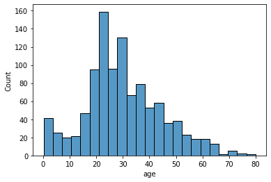

```python
sns.histplot(df['age']);
```

Imputing missing numeric values: use mean is there is a standard distribution and median if the data is skewed

Imputing categorical values: use mode

In this case, mean = 30 and median = 28

```python
df.loc[df.age.isnull(), 'age'] = 30
# df['age'] = df['age'].replace(np.nan, ??)
```

```python
df.age.isnull().sum()
```

```
0
```

```python
# how did this affect the column's statistics?
df.age.describe().T
```

```
count    1309.000000
mean       29.905019
std        12.883281
min         0.170000
25%        22.000000
50%        30.000000
75%        35.000000
max        80.000000
Name: age, dtype: float64
```

```python
df['fare'].isnull().sum()
```

```
1
```

```python
df[df['fare'].isnull()]
```

|  | pclass | survived | name | sex | age | sibsp | parch | ticket | fare | cabin | embarked |
| --- | --- | --- | --- | --- | --- | --- | --- | --- | --- | --- | --- |
| 1226 | 3 | 0 | Storey, Mr. Thomas | male | 60.5 | 0 | 0 | 3701 | NaN | NaN | S |

```python
df.fare.describe().T
```

```
count    1308.000000
mean       33.295479
std        51.758668
min         0.000000
25%         7.895800
50%        14.454200
75%        31.275000
max       512.329200
Name: fare, dtype: float64
```

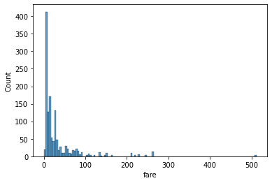

```python
sns.histplot(df['fare']);
```

```python
df.loc[df.fare.isnull(), 'fare'] = df.fare.median()
# df['fare'] = df['fare'].replace(np.nan, df.fare.median())
```

```python
df.fare.describe().T
```

```
count    1309.000000
mean       33.281086
std        51.741500
min         0.000000
25%         7.895800
50%        14.454200
75%        31.275000
max       512.329200
Name: fare, dtype: float64
```

```python
df['cabin'].isnull().sum()
```

```
1014
```

Over 75% of the rows do not have a value for the cabin column. With that many columns missing, it is best to delete the column

```python
df = df.drop(['cabin'], axis=1)
```

```python
df.sample(10)
```

|  | pclass | survived | name | sex | age | sibsp | parch | ticket | fare | embarked |
| --- | --- | --- | --- | --- | --- | --- | --- | --- | --- | --- |
| 541 | 2 | 1 | Quick, Miss. Phyllis May | female | 2.0 | 1 | 1 | 26360 | 26.0000 | S |
| 1136 | 3 | 0 | Radeff, Mr. Alexander | male | 30.0 | 0 | 0 | 349223 | 7.8958 | S |
| 1232 | 3 | 0 | Strom, Mrs. Wilhelm (Elna Matilda Persson) | female | 29.0 | 1 | 1 | 347054 | 10.4625 | S |
| 234 | 1 | 1 | Potter, Mrs. Thomas Jr (Lily Alexenia Wilson) | female | 56.0 | 0 | 1 | 11767 | 83.1583 | C |
| 610 | 3 | 0 | Adams, Mr. John | male | 26.0 | 0 | 0 | 341826 | 8.0500 | S |
| 750 | 3 | 0 | Danbom, Mrs. Ernst Gilbert (Anna Sigrid Maria ... | female | 28.0 | 1 | 1 | 347080 | 14.4000 | S |
| 1110 | 3 | 0 | Paulner, Mr. Uscher | male | 30.0 | 0 | 0 | 3411 | 8.7125 | C |
| 242 | 1 | 0 | Rood, Mr. Hugh Roscoe | male | 30.0 | 0 | 0 | 113767 | 50.0000 | S |
| 391 | 2 | 0 | Deacon, Mr. Percy William | male | 17.0 | 0 | 0 | S.O.C. 14879 | 73.5000 | S |
| 236 | 1 | 1 | Rheims, Mr. George Alexander Lucien | male | 30.0 | 0 | 0 | PC 17607 | 39.6000 | S |

```python
df['embarked'].isnull().sum()
```

```
2
```

```python
df[df['embarked'].isnull()]
```

|  | pclass | survived | name | sex | age | sibsp | parch | ticket | fare | embarked |
| --- | --- | --- | --- | --- | --- | --- | --- | --- | --- | --- |
| 169 | 1 | 1 | Icard, Miss. Amelie | female | 38.0 | 0 | 0 | 113572 | 80.0 | NaN |
| 285 | 1 | 1 | Stone, Mrs. George Nelson (Martha Evelyn) | female | 62.0 | 0 | 0 | 113572 | 80.0 | NaN |

```python
df['embarked'].mode()
```

```
0    S
Name: embarked, dtype: object
```

```python
df['embarked'].value_counts()
```

```
S    914
C    270
Q    123
Name: embarked, dtype: int64
```

```python
#df.loc[df.embarked.isnull(), 'age'] = 30
df['embarked'] = df['embarked'].replace(np.nan, 'S')
```

```python
# verify there aren't any missing values
df.isnull().sum()
```

```
pclass      0
survived    0
name        0
sex         0
age         0
sibsp       0
parch       0
ticket      0
fare        0
embarked    0
dtype: int64
```

#### Handle outliers

```python
df.describe().T
```

|  | count | mean | std | min | 25% | 50% | 75% | max |
| --- | --- | --- | --- | --- | --- | --- | --- | --- |
| pclass | 1309.0 | 2.294882 | 0.837836 | 1.00 | 2.0000 | 3.0000 | 3.000 | 3.0000 |
| survived | 1309.0 | 0.381971 | 0.486055 | 0.00 | 0.0000 | 0.0000 | 1.000 | 1.0000 |
| age | 1309.0 | 29.905019 | 12.883281 | 0.17 | 22.0000 | 30.0000 | 35.000 | 80.0000 |
| sibsp | 1309.0 | 0.498854 | 1.041658 | 0.00 | 0.0000 | 0.0000 | 1.000 | 8.0000 |
| parch | 1309.0 | 0.385027 | 0.865560 | 0.00 | 0.0000 | 0.0000 | 0.000 | 9.0000 |
| fare | 1309.0 | 33.281086 | 51.741500 | 0.00 | 7.8958 | 14.4542 | 31.275 | 512.3292 |

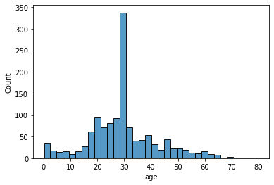

```python
sns.histplot(df['age']);
```

```python
df.fare.describe().T
```

```
count    1309.000000
mean       33.281086
std        51.741500
min         0.000000
25%         7.895800
50%        14.454200
75%        31.275000
max       512.329200
Name: fare, dtype: float64
```

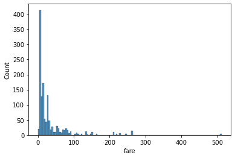

```python
sns.histplot(df['fare']);
```

```python
df[df['fare'] > 500]
```

|  | pclass | survived | name | sex | age | sibsp | parch | ticket | fare | embarked |
| --- | --- | --- | --- | --- | --- | --- | --- | --- | --- | --- |
| 50 | 1 | 1 | Cardeza, Mr. Thomas Drake Martinez | male | 36.0 | 0 | 1 | PC 17755 | 512.3292 | C |
| 51 | 1 | 1 | Cardeza, Mrs. James Warburton Martinez (Charlo... | female | 58.0 | 0 | 1 | PC 17755 | 512.3292 | C |
| 184 | 1 | 1 | Lesurer, Mr. Gustave J | male | 35.0 | 0 | 0 | PC 17755 | 512.3292 | C |
| 303 | 1 | 1 | Ward, Miss. Anna | female | 35.0 | 0 | 0 | PC 17755 | 512.3292 | C |

```python
df.groupby("pclass")["fare"].median()
```

```
pclass
1    60.0000
2    15.0458
3     8.0500
Name: fare, dtype: float64
```

```python
# update the 51232.92 fare prices with the median fare price for pclass 1
df.loc[df['fare'] == 512.3292, ['fare']] = 60
```

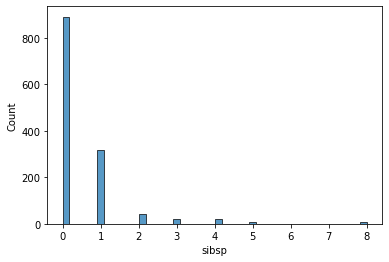

```python
sns.histplot(df['sibsp']);
```

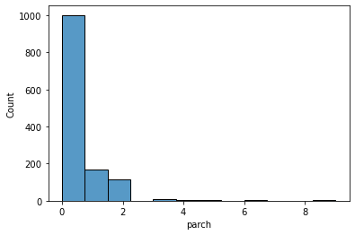

```python
sns.histplot(df['parch']);
```

#### Check for inconsistent data in the columns

```python
df.dtypes
```

```
pclass        int64
survived      int64
name         object
sex          object
age         float64
sibsp         int64
parch         int64
ticket       object
fare        float64
embarked     object
dtype: object
```

```python
df['sex'].value_counts()
```

```
male       843
female     462
fe male      4
Name: sex, dtype: int64
```

```python
# update 'fe male' values to 'female'
df.loc[df['sex'] == 'fe male', ['sex']] = 'female'
```

```python
df['sex'].value_counts()
```

```
male      843
female    466
Name: sex, dtype: int64
```

```python
df['embarked'].value_counts()
```

```
S    916
C    270
Q    123
Name: embarked, dtype: int64
```

```python
df['sibsp'].value_counts()
```

```
0    891
1    319
2     42
4     22
3     20
8      9
5      6
Name: sibsp, dtype: int64
```

```python
df['parch'].value_counts()
```

```
0    1002
1     170
2     113
3       8
4       6
5       6
6       2
9       2
Name: parch, dtype: int64
```

#### Delete columns that do not affect the prediction or target value

```python
df.nunique()
```

```
pclass         3
survived       2
name        1307
sex            2
age           98
sibsp          7
parch          8
ticket       929
fare         280
embarked       3
dtype: int64
```

```python
df.sample(20)
```

|  | pclass | survived | name | sex | age | sibsp | parch | ticket | fare | embarked |
| --- | --- | --- | --- | --- | --- | --- | --- | --- | --- | --- |
| 673 | 3 | 0 | Betros, Master. Seman | male | 30.0 | 0 | 0 | 2622 | 7.2292 | C |
| 350 | 2 | 1 | Brown, Miss. Amelia "Mildred" | female | 24.0 | 0 | 0 | 248733 | 13.0000 | S |
| 730 | 3 | 0 | Cor, Mr. Bartol | male | 35.0 | 0 | 0 | 349230 | 7.8958 | S |
| 1155 | 3 | 0 | Rogers, Mr. William John | male | 30.0 | 0 | 0 | S.C./A.4. 23567 | 8.0500 | S |
| 310 | 1 | 1 | Wick, Miss. Mary Natalie | female | 31.0 | 0 | 2 | 36928 | 164.8667 | S |
| 430 | 2 | 0 | Harbeck, Mr. William H | male | 44.0 | 0 | 0 | 248746 | 13.0000 | S |
| 491 | 2 | 0 | Mack, Mrs. (Mary) | female | 57.0 | 0 | 0 | S.O./P.P. 3 | 10.5000 | S |
| 251 | 1 | 1 | Ryerson, Miss. Emily Borie | female | 18.0 | 2 | 2 | PC 17608 | 262.3750 | C |
| 669 | 3 | 0 | Barton, Mr. David John | male | 22.0 | 0 | 0 | 324669 | 8.0500 | S |
| 603 | 3 | 0 | Abbott, Mr. Rossmore Edward | male | 16.0 | 1 | 1 | C.A. 2673 | 20.2500 | S |
| 685 | 3 | 0 | Bourke, Mrs. John (Catherine) | female | 32.0 | 1 | 1 | 364849 | 15.5000 | Q |
| 607 | 3 | 1 | Abrahamsson, Mr. Abraham August Johannes | male | 20.0 | 0 | 0 | SOTON/O2 3101284 | 7.9250 | S |
| 287 | 1 | 0 | Straus, Mrs. Isidor (Rosalie Ida Blun) | female | 63.0 | 1 | 0 | PC 17483 | 221.7792 | S |
| 660 | 3 | 1 | Baclini, Miss. Marie Catherine | female | 5.0 | 2 | 1 | 2666 | 19.2583 | C |
| 674 | 3 | 0 | Betros, Mr. Tannous | male | 20.0 | 0 | 0 | 2648 | 4.0125 | C |
| 1029 | 3 | 1 | Moran, Miss. Bertha | female | 30.0 | 1 | 0 | 371110 | 24.1500 | Q |
| 7 | 1 | 1 | Andrews, Miss. Kornelia Theodosia | female | 63.0 | 1 | 0 | 13502 | 77.9583 | S |
| 1190 | 3 | 1 | Sandstrom, Miss. Marguerite Rut | female | 4.0 | 1 | 1 | PP 9549 | 16.7000 | S |
| 1169 | 3 | 0 | Sadowitz, Mr. Harry | male | 30.0 | 0 | 0 | LP 1588 | 7.5750 | S |
| 157 | 1 | 0 | Head, Mr. Christopher | male | 42.0 | 0 | 0 | 113038 | 42.5000 | S |

```python
## name - all but two rows are unique values - at this point we will keep name because there are things that we
#         may be able to draw out later - last name, title
```

```python
## ticket - ticket number does not have an effect on our target number
```

```python
df = df.drop(['ticket'], axis=1)
```

```python
df.sample(20)
```

|  | pclass | survived | name | sex | age | sibsp | parch | fare | embarked |
| --- | --- | --- | --- | --- | --- | --- | --- | --- | --- |
| 877 | 3 | 0 | Ilieff, Mr. Ylio | male | 30.00 | 0 | 0 | 7.8958 | S |
| 457 | 2 | 0 | Howard, Mrs. Benjamin (Ellen Truelove Arman) | female | 60.00 | 1 | 0 | 26.0000 | S |
| 508 | 2 | 0 | Montvila, Rev. Juozas | male | 27.00 | 0 | 0 | 13.0000 | S |
| 1020 | 3 | 0 | Mineff, Mr. Ivan | male | 24.00 | 0 | 0 | 7.8958 | S |
| 503 | 2 | 1 | Mellinger, Mrs. (Elizabeth Anne Maidment) | female | 41.00 | 0 | 1 | 19.5000 | S |
| 1134 | 3 | 0 | Pokrnic, Mr. Mate | male | 17.00 | 0 | 0 | 8.6625 | S |
| 21 | 1 | 1 | Beckwith, Mr. Richard Leonard | male | 37.00 | 1 | 1 | 52.5542 | S |
| 627 | 3 | 0 | Andersson, Miss. Ida Augusta Margareta | female | 38.00 | 4 | 2 | 7.7750 | S |
| 277 | 1 | 0 | Spencer, Mr. William Augustus | male | 57.00 | 1 | 0 | 146.5208 | C |
| 362 | 2 | 1 | Caldwell, Mrs. Albert Francis (Sylvia Mae Harb... | female | 22.00 | 1 | 1 | 29.0000 | S |
| 589 | 2 | 1 | Wells, Miss. Joan | female | 4.00 | 1 | 1 | 23.0000 | S |
| 653 | 3 | 0 | Augustsson, Mr. Albert | male | 23.00 | 0 | 0 | 7.8542 | S |
| 991 | 3 | 0 | Makinen, Mr. Kalle Edvard | male | 29.00 | 0 | 0 | 7.9250 | S |
| 549 | 2 | 1 | Richards, Master. George Sibley | male | 0.83 | 1 | 1 | 18.7500 | S |
| 869 | 3 | 0 | Holm, Mr. John Fredrik Alexander | male | 43.00 | 0 | 0 | 6.4500 | S |
| 1081 | 3 | 1 | O'Keefe, Mr. Patrick | male | 30.00 | 0 | 0 | 7.7500 | Q |
| 120 | 1 | 1 | Frauenthal, Dr. Henry William | male | 50.00 | 2 | 0 | 133.6500 | S |
| 570 | 2 | 0 | Sweet, Mr. George Frederick | male | 14.00 | 0 | 0 | 65.0000 | S |
| 401 | 2 | 1 | Drew, Mrs. James Vivian (Lulu Thorne Christian) | female | 34.00 | 1 | 1 | 32.5000 | S |
| 726 | 3 | 1 | Connolly, Miss. Kate | female | 22.00 | 0 | 0 | 7.7500 | Q |

## Exploratory Data Analysis

### user defined functions for visualizations to use

```python
def histogram_boxplot(data, feature, figsize=(12, 7), kde=False, bins=None):
    """
    Boxplot and histogram combined

    data: dataframe
    feature: dataframe column
    figsize: size of figure (default (12,7))
    kde: whether to show the density curve (default False)
    bins: number of bins for histogram (default None)
    """
    f2, (ax_box2, ax_hist2) = plt.subplots(
        nrows=2,  # Number of rows of the subplot grid= 2
        sharex=True,  # x-axis will be shared among all subplots
        gridspec_kw={"height_ratios": (0.25, 0.75)},
        figsize=figsize,
    )  # creating the 2 subplots

    sns.boxplot(
        data=data, x=feature, ax=ax_box2, showmeans=True, color="violet"
    )  # boxplot will be created and a star will indicate the mean value of the column

    sns.histplot(
        data=data, x=feature, kde=kde, ax=ax_hist2, bins=bins, palette="winter"
    ) if bins else sns.histplot(
        data=data, x=feature, kde=kde, ax=ax_hist2
    )  # For histogram

    ax_hist2.axvline(
        data[feature].mean(), color="green", linestyle="--"
    )  # Add mean to the histogram

    ax_hist2.axvline(
        data[feature].median(), color="black", linestyle="-"
    )  # Add median to the histogram
```

```python
print (histogram_boxplot.__doc__)
```

```
    Boxplot and histogram combined

    data: dataframe
    feature: dataframe column
    figsize: size of figure (default (12,7))
    kde: whether to show the density curve (default False)
    bins: number of bins for histogram (default None)
```

```python
histogram_boxplot(df, 'age',kde=True)
```

[output not shown]

```python
# function to create labeled barplots


def labeled_barplot(data, feature, perc=False, n=None):
    """
    Barplot with percentage at the top

    data: dataframe
    feature: dataframe column
    perc: whether to display percentages instead of count (default is False)
    n: displays the top n category levels (default is None, i.e., display all levels)
    """

    total = len(data[feature])  # length of the feature - number of rows
    count = data[feature].nunique() # unique values of the feature
    if n is None:
        plt.figure(figsize=(count + 1, 5))
    else:
        plt.figure(figsize=(n + 1, 5))

    plt.xticks(rotation=90, fontsize=15)
    ax = sns.countplot(
        data=data,
        x=feature,
        palette="Paired",
        order=data[feature].value_counts().index[:n].sort_values(),
    )

    for p in ax.patches:
        if perc == True:
            label = "{:.1f}%".format(
                100 * p.get_height() / total
            )  # percentage of each class of the category
        else:
            label = p.get_height()  # count of each level of the category

        x = p.get_x() + p.get_width() / 2  # width of the plot
        y = p.get_height()  # height of the plot

        ax.annotate(
            label,
            (x, y),
            ha="center",
            va="center",
            size=12,
            xytext=(0, 5),
            textcoords="offset points",
        )  # annotate the percentage

    plt.show()  # show the plot
```

```python
print (labeled_barplot.__doc__)
```

```
    Barplot with percentage at the top

    data: dataframe
    feature: dataframe column
    perc: whether to display percentages instead of count (default is False)
    n: displays the top n category levels (default is None, i.e., display all levels)
```

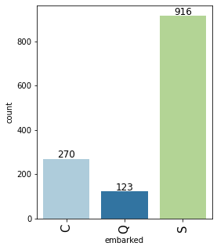

```python
labeled_barplot(df, 'embarked')
```

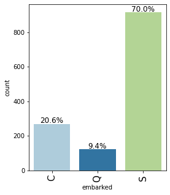

```python
labeled_barplot(df, 'embarked', perc=True)
```

```python
def stacked_barplot(data, predictor, target):
    """
    Print the category counts and plot a stacked bar chart

    data: dataframe
    predictor: independent variable
    target: target variable
    """
    count = data[predictor].nunique() # unique values of the feature
    sorter = data[target].value_counts().index[-1]
    tab1 = pd.crosstab(data[predictor], data[target], margins=True).sort_values(
        by=sorter, ascending=False
    )
    print(tab1)
    print("-" * 115)
    tab = pd.crosstab(data[predictor], data[target], normalize="index").sort_values(
        by=sorter, ascending=False
    )
    print(tab)
    tab.plot(kind="bar", stacked=True, figsize=(count + 5, 5))
    plt.legend(
        loc="lower left", frameon=False,
    )
    plt.legend(loc="upper left", bbox_to_anchor=(1, 1))
    plt.show()
```

```python
print (stacked_barplot.__doc__)
```

```
    Print the category counts and plot a stacked bar chart

    data: dataframe
    predictor: independent variable
    target: target variable
```

```
survived    0    1   All
embarked
All       809  500  1309
S         610  306   916
C         120  150   270
Q          79   44   123
-------------------------------------------------------------------------------------------------------------------
survived         0         1
embarked
C         0.444444  0.555556
Q         0.642276  0.357724
S         0.665939  0.334061
```

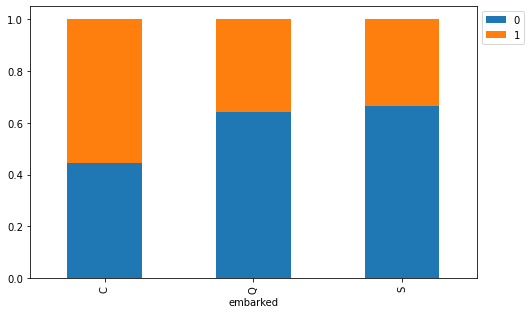

```python
stacked_barplot(df, 'embarked', 'survived')
```

### Univariate Analysis

#### Explore the numeric features - age, fare

#### Age

```python
df.age.describe()
```

```
count    1309.000000
mean       29.905019
std        12.883281
min         0.170000
25%        22.000000
50%        30.000000
75%        35.000000
max        80.000000
Name: age, dtype: float64
```

```python
histogram_boxplot(df, 'age',kde=True)
```

[output not shown]

Observation:

#### Fare

```python
df.fare.describe()
```

```
count    1309.000000
mean       31.898873
std        44.448381
min         0.000000
25%         7.895800
50%        14.454200
75%        31.275000
max       263.000000
Name: fare, dtype: float64
```

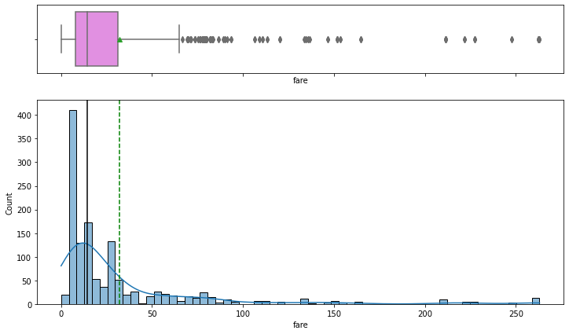

```python
histogram_boxplot(df, 'fare',kde=True)
```

Observation:

#### sibsp

```python
df.sibsp.describe()
```

```
count    1309.000000
mean        0.498854
std         1.041658
min         0.000000
25%         0.000000
50%         0.000000
75%         1.000000
max         8.000000
Name: sibsp, dtype: float64
```

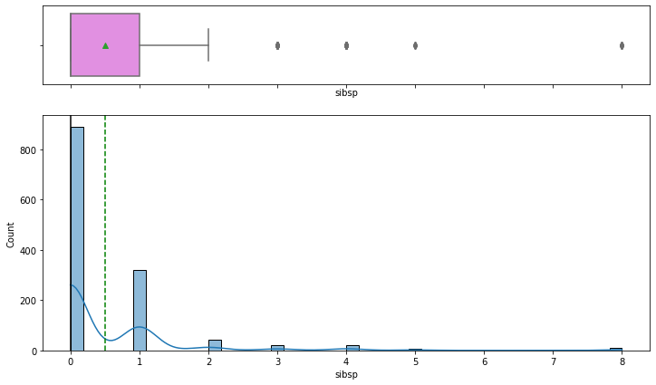

```python
histogram_boxplot(df, 'sibsp',kde=True)
```

Observation:

#### parch

```python
df.parch.describe()
```

```
count    1309.000000
mean        0.385027
std         0.865560
min         0.000000
25%         0.000000
50%         0.000000
75%         0.000000
max         9.000000
Name: parch, dtype: float64
```

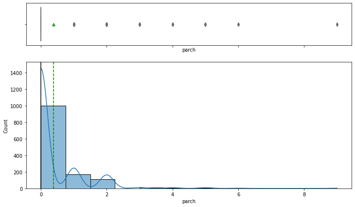

```python
histogram_boxplot(df, 'parch',kde=True)
```

Observation:

#### Explore categorical features - survived, pclass, sex, sibsp, parch, embarked

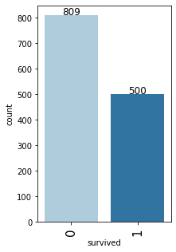

```python
labeled_barplot(df, 'survived')
```

Observation: 809 passengers did not survive and 500 did survive

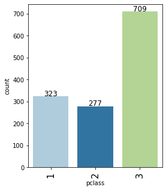

```python
labeled_barplot(df, 'pclass')
```

Observation:

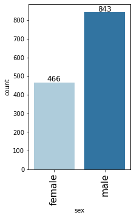

```python
labeled_barplot(df, 'sex')
```

Observation:

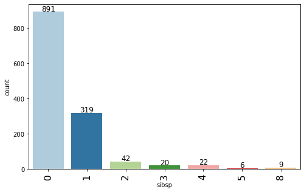

```python
labeled_barplot(df, 'sibsp')
```

Observation:

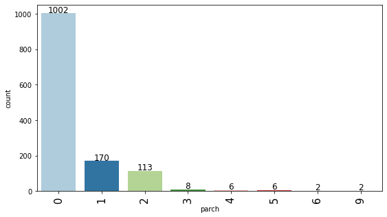

```python
labeled_barplot(df, 'parch')
```

Observation:

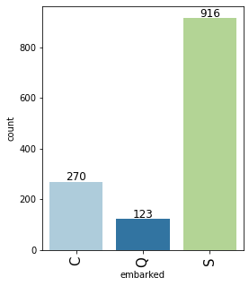

```python
labeled_barplot(df, 'embarked')
```

Observation:

### Bivariate Analysis

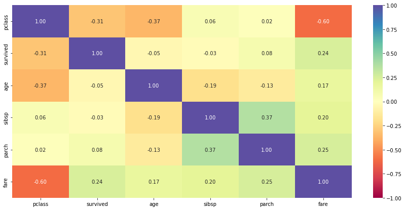

```python
plt.figure(figsize=(15, 7))
sns.heatmap(df.corr(), annot=True, vmin=-1, vmax=1, fmt=".2f", cmap="Spectral")
plt.show()
```

Observation:

- sibsp and parch most positively correlated pair of features
- fare and pclass most negatively correlated pair of features

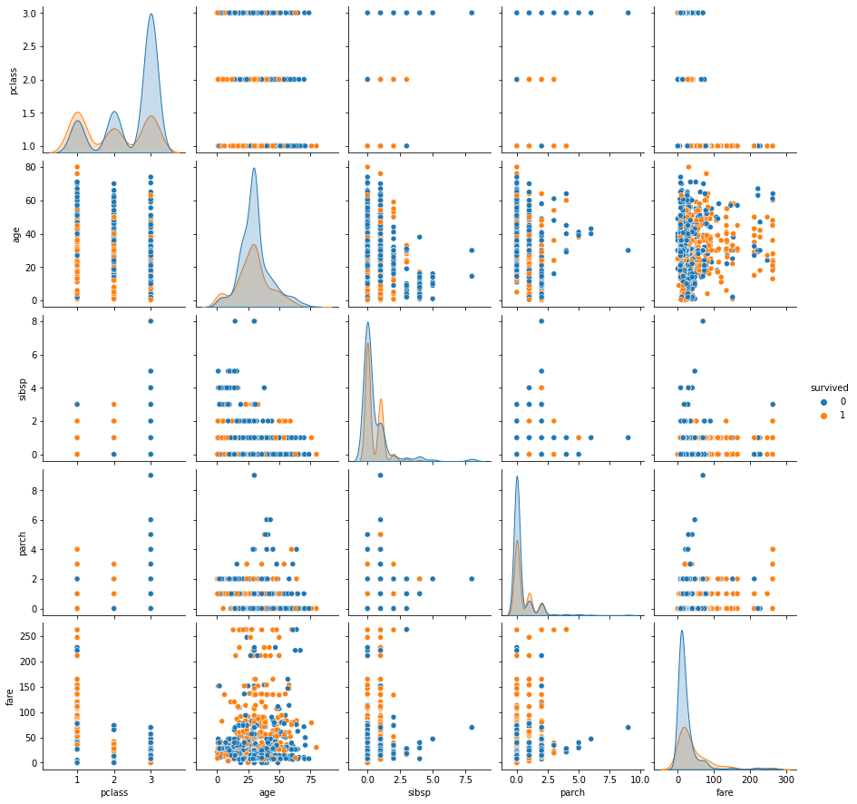

```python
sns.pairplot(data=df,hue='survived')
```

Observation:

- Age/Fare is an intesting scatterplot. Age is equally disperse across the fare prices. Fare you can really see the distinction between passengers who survived and who didn't. Low fare = less survival

#### pclass

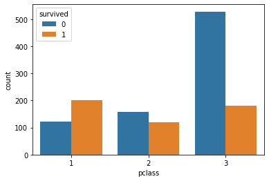

```python
sns.countplot(x='pclass', hue='survived', data=df)
```

```
survived    0    1   All
pclass
All       809  500  1309
1         123  200   323
3         528  181   709
2         158  119   277
-------------------------------------------------------------------------------------------------------------------
survived         0         1
pclass
1         0.380805  0.619195
2         0.570397  0.429603
3         0.744711  0.255289
```

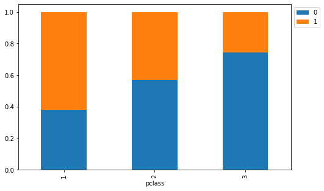

```python
stacked_barplot(df, 'pclass', 'survived')
```

Observation:

Survival rate for 1st class - 62% # of passengers in 1st class = 323

Survival rate for 2nd class - 43% # of passengers in 2nd class = 277

Survival rate for 3rd class - 26% # of passengers in 3rd class = 709

#### sex

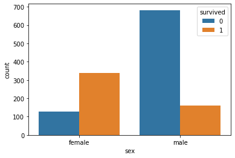

```python
sns.countplot(x='sex', hue='survived', data=df)
```

```
survived    0    1   All
sex
All       809  500  1309
female    127  339   466
male      682  161   843
-------------------------------------------------------------------------------------------------------------------
survived         0         1
sex
female    0.272532  0.727468
male      0.809015  0.190985
```

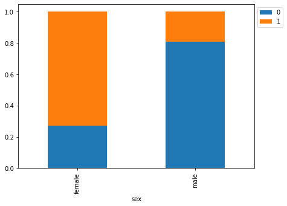

```python
stacked_barplot(df, 'sex', 'survived')
```

Observation:

```python
pd.crosstab([df.sex,df.survived],df.pclass,margins=True)
```

| sex | pclass survived | 1 | 2 | 3 | All |
| --- | --- | --- | --- | --- | --- |
| female | 0 | 5 | 12 | 110 | 127 |
|  | 1 | 139 | 94 | 106 | 339 |
| male | 0 | 118 | 146 | 418 | 682 |
|  | 1 | 61 | 25 | 75 | 161 |
| All |  | 323 | 277 | 709 | 1309 |

Observation:

#### sibsp

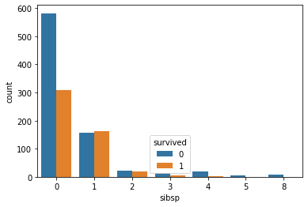

```python
sns.countplot(x='sibsp', hue='survived', data=df)
```

```
survived    0    1   All
sibsp
All       809  500  1309
0         582  309   891
1         156  163   319
2          23   19    42
3          14    6    20
4          19    3    22
5           6    0     6
8           9    0     9
-------------------------------------------------------------------------------------------------------------------
survived         0         1
sibsp
1         0.489028  0.510972
2         0.547619  0.452381
0         0.653199  0.346801
3         0.700000  0.300000
4         0.863636  0.136364
5         1.000000  0.000000
8         1.000000  0.000000
```

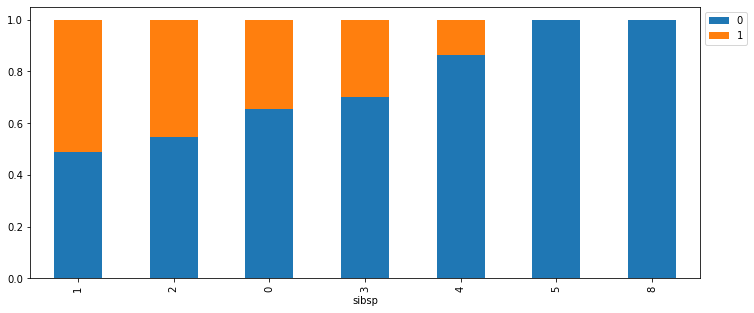

```python
stacked_barplot(df, 'sibsp', 'survived')
```

Observation:

#### parch

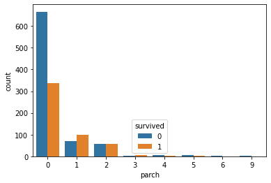

```python
sns.countplot(x='parch', hue='survived', data=df)
```

```
survived    0    1   All
parch
All       809  500  1309
0         666  336  1002
1          70  100   170
2          56   57   113
3           3    5     8
4           5    1     6
5           5    1     6
6           2    0     2
9           2    0     2
-------------------------------------------------------------------------------------------------------------------
survived         0         1
parch
3         0.375000  0.625000
1         0.411765  0.588235
2         0.495575  0.504425
0         0.664671  0.335329
4         0.833333  0.166667
5         0.833333  0.166667
6         1.000000  0.000000
9         1.000000  0.000000
```

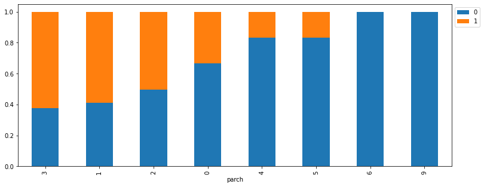

```python
stacked_barplot(df, 'parch', 'survived')
```

Observation:

#### embarked

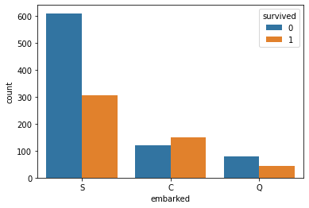

```python
sns.countplot(x='embarked', hue='survived', data=df)
```

```
survived    0    1   All
embarked
All       809  500  1309
S         610  306   916
C         120  150   270
Q          79   44   123
-------------------------------------------------------------------------------------------------------------------
survived         0         1
embarked
C         0.444444  0.555556
Q         0.642276  0.357724
S         0.665939  0.334061
```

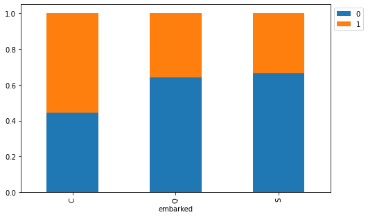

```python
stacked_barplot(df, 'embarked', 'survived')
```

Observation:

#### age

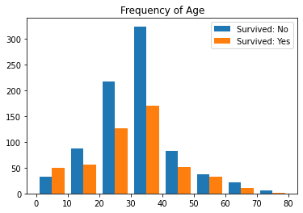

```python
# Bin frequency
dt0 = df['age'][df['survived']==0]
dt1 = df['age'][df['survived']==1]

bins = np.arange(0, df['age'].max()+10, 10)

plt.hist([dt0,dt1], label=['Survived: No','Survived: Yes'], bins=bins)

plt.legend(loc='upper right')
plt.title('Frequency of Age');
```

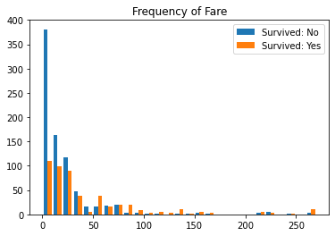

```python
# Bin frequency
dt0 = df['fare'][df['survived']==0]
dt1 = df['fare'][df['survived']==1]

bins = np.arange(0, df['fare'].max()+10, 10)

plt.hist([dt0,dt1], label=['Survived: No','Survived: Yes'], bins=bins)

plt.legend(loc='upper right')
plt.title('Frequency of Fare');
```

Observation:

#### fare

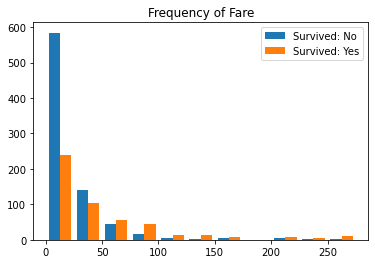

```python
# Bin frequency
dt0 = df['fare'][df['survived']==0]
dt1 = df['fare'][df['survived']==1]

bins = np.arange(0, df['fare'].max()+25, 25)

plt.hist([dt0,dt1], label=['Survived: No','Survived: Yes'], bins=bins)

plt.legend(loc='upper right')
plt.title('Frequency of Fare');
```

Observation:

## Feature Engineering

```python
data = df.copy()
```

### Feature Scaling

#### Standardization

```python
df.head()
```

|  | pclass | survived | name | sex | age | sibsp | parch | fare | embarked |
| --- | --- | --- | --- | --- | --- | --- | --- | --- | --- |
| 0 | 1 | 1 | Allen, Miss. Elisabeth Walton | female | 29.00 | 0 | 0 | 211.3375 | S |
| 1 | 1 | 1 | Allison, Master. Hudson Trevor | male | 0.92 | 1 | 2 | 151.5500 | S |
| 3 | 1 | 0 | Allison, Miss. Helen Loraine | female | 2.00 | 1 | 2 | 151.5500 | S |
| 4 | 1 | 0 | Allison, Mr. Hudson Joshua Creighton | male | 30.00 | 1 | 2 | 151.5500 | S |
| 5 | 1 | 0 | Allison, Mrs. Hudson J C (Bessie Waldo Daniels) | female | 25.00 | 1 | 2 | 151.5500 | S |

```python
histogram_boxplot(df, 'age',kde=True)
```

[output not shown]

```python
from sklearn.preprocessing import StandardScaler

scaler = StandardScaler()
scaler.fit(df[['age']])
df[['age']] = scaler.transform(df[['age']])
```

```python
df['age']
```

```
0      -0.070274
1      -2.250676
3      -2.166815
4       0.007375
5      -0.380873
          ...
1305   -1.196194
1306    0.007375
1307   -0.264399
1308   -0.225574
1309   -0.070274
Name: age, Length: 1309, dtype: float64
```

```python
df[['age']]
```

|  | age |
| --- | --- |
| 0 | -0.070274 |
| 1 | -2.250676 |
| 3 | -2.166815 |
| 4 | 0.007375 |
| 5 | -0.380873 |
| ... | ... |
| 1305 | -1.196194 |
| 1306 | 0.007375 |
| 1307 | -0.264399 |
| 1308 | -0.225574 |
| 1309 | -0.070274 |

1309 rows × 1 columns

```python
df.head()
```

|  | pclass | survived | name | sex | age | sibsp | parch | fare | embarked |
| --- | --- | --- | --- | --- | --- | --- | --- | --- | --- |
| 0 | 1 | 1 | Allen, Miss. Elisabeth Walton | female | -0.070274 | 0 | 0 | 211.3375 | S |
| 1 | 1 | 1 | Allison, Master. Hudson Trevor | male | -2.250676 | 1 | 2 | 151.5500 | S |
| 3 | 1 | 0 | Allison, Miss. Helen Loraine | female | -2.166815 | 1 | 2 | 151.5500 | S |
| 4 | 1 | 0 | Allison, Mr. Hudson Joshua Creighton | male | 0.007375 | 1 | 2 | 151.5500 | S |
| 5 | 1 | 0 | Allison, Mrs. Hudson J C (Bessie Waldo Daniels) | female | -0.380873 | 1 | 2 | 151.5500 | S |

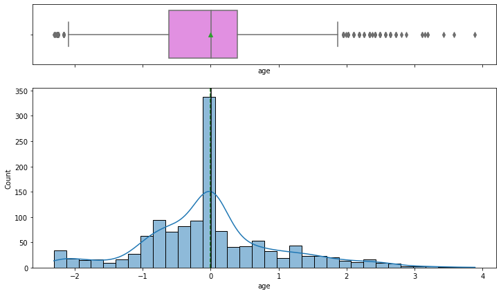

```python
histogram_boxplot(df, 'age',kde=True)
```

```python
df.age.describe()
```

```
count    1.309000e+03
mean    -9.331726e-17
std      1.000382e+00
min     -2.308914e+00
25%     -6.138219e-01
50%      7.375233e-03
75%      3.956234e-01
max      3.889857e+00
Name: age, dtype: float64
```

#### Min/Max Scaling

```python
df = data.copy()
```

```python
df.head()
```

|  | pclass | survived | name | sex | age | sibsp | parch | fare | embarked |
| --- | --- | --- | --- | --- | --- | --- | --- | --- | --- |
| 0 | 1 | 1 | Allen, Miss. Elisabeth Walton | female | 29.00 | 0 | 0 | 211.3375 | S |
| 1 | 1 | 1 | Allison, Master. Hudson Trevor | male | 0.92 | 1 | 2 | 151.5500 | S |
| 3 | 1 | 0 | Allison, Miss. Helen Loraine | female | 2.00 | 1 | 2 | 151.5500 | S |
| 4 | 1 | 0 | Allison, Mr. Hudson Joshua Creighton | male | 30.00 | 1 | 2 | 151.5500 | S |
| 5 | 1 | 0 | Allison, Mrs. Hudson J C (Bessie Waldo Daniels) | female | 25.00 | 1 | 2 | 151.5500 | S |

```python
histogram_boxplot(df, 'age',kde=True)
```

[output not shown]

```python
from sklearn.preprocessing import MinMaxScaler

scaler = MinMaxScaler()
scaler.fit(df[['age']])
df[['age']] = scaler.transform(df[['age']])
```

```python
df.head()
```

|  | pclass | survived | name | sex | age | sibsp | parch | fare | embarked |
| --- | --- | --- | --- | --- | --- | --- | --- | --- | --- |
| 0 | 1 | 1 | Allen, Miss. Elisabeth Walton | female | 0.361142 | 0 | 0 | 211.3375 | S |
| 1 | 1 | 1 | Allison, Master. Hudson Trevor | male | 0.009395 | 1 | 2 | 151.5500 | S |
| 3 | 1 | 0 | Allison, Miss. Helen Loraine | female | 0.022924 | 1 | 2 | 151.5500 | S |
| 4 | 1 | 0 | Allison, Mr. Hudson Joshua Creighton | male | 0.373669 | 1 | 2 | 151.5500 | S |
| 5 | 1 | 0 | Allison, Mrs. Hudson J C (Bessie Waldo Daniels) | female | 0.311036 | 1 | 2 | 151.5500 | S |

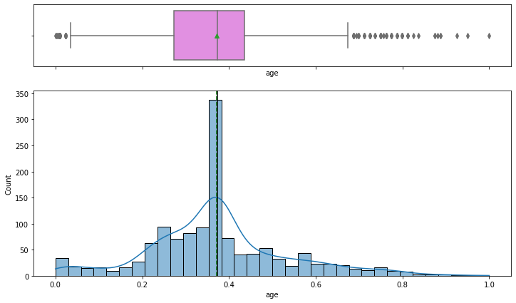

```python
histogram_boxplot(df, 'age',kde=True)
```

### Encoding categorical features

#### One Hot Encoding

```python
df.embarked.unique()
```

```
array(['S', 'C', 'Q'], dtype=object)
```

```python
df.head(10)
```

|  | pclass | survived | name | sex | age | sibsp | parch | fare | embarked |
| --- | --- | --- | --- | --- | --- | --- | --- | --- | --- |
| 0 | 1 | 1 | Allen, Miss. Elisabeth Walton | female | 0.361142 | 0 | 0 | 211.3375 | S |
| 1 | 1 | 1 | Allison, Master. Hudson Trevor | male | 0.009395 | 1 | 2 | 151.5500 | S |
| 3 | 1 | 0 | Allison, Miss. Helen Loraine | female | 0.022924 | 1 | 2 | 151.5500 | S |
| 4 | 1 | 0 | Allison, Mr. Hudson Joshua Creighton | male | 0.373669 | 1 | 2 | 151.5500 | S |
| 5 | 1 | 0 | Allison, Mrs. Hudson J C (Bessie Waldo Daniels) | female | 0.311036 | 1 | 2 | 151.5500 | S |
| 6 | 1 | 1 | Anderson, Mr. Harry | male | 0.599148 | 0 | 0 | 26.5500 | S |
| 7 | 1 | 1 | Andrews, Miss. Kornelia Theodosia | female | 0.787047 | 1 | 0 | 77.9583 | S |
| 8 | 1 | 0 | Andrews, Mr. Thomas Jr | male | 0.486409 | 0 | 0 | 0.0000 | S |
| 9 | 1 | 1 | Appleton, Mrs. Edward Dale (Charlotte Lamson) | female | 0.661781 | 2 | 0 | 51.4792 | S |
| 10 | 1 | 0 | Artagaveytia, Mr. Ramon | male | 0.887260 | 0 | 0 | 49.5042 | C |

```python
df = pd.get_dummies(df, columns=['embarked'], drop_first=True)
```

```python
df.head(10)
```

|  | pclass | survived | name | sex | age | sibsp | parch | fare | embarked_Q | embarked_S |
| --- | --- | --- | --- | --- | --- | --- | --- | --- | --- | --- |
| 0 | 1 | 1 | Allen, Miss. Elisabeth Walton | female | 0.361142 | 0 | 0 | 211.3375 | 0 | 1 |
| 1 | 1 | 1 | Allison, Master. Hudson Trevor | male | 0.009395 | 1 | 2 | 151.5500 | 0 | 1 |
| 3 | 1 | 0 | Allison, Miss. Helen Loraine | female | 0.022924 | 1 | 2 | 151.5500 | 0 | 1 |
| 4 | 1 | 0 | Allison, Mr. Hudson Joshua Creighton | male | 0.373669 | 1 | 2 | 151.5500 | 0 | 1 |
| 5 | 1 | 0 | Allison, Mrs. Hudson J C (Bessie Waldo Daniels) | female | 0.311036 | 1 | 2 | 151.5500 | 0 | 1 |
| 6 | 1 | 1 | Anderson, Mr. Harry | male | 0.599148 | 0 | 0 | 26.5500 | 0 | 1 |
| 7 | 1 | 1 | Andrews, Miss. Kornelia Theodosia | female | 0.787047 | 1 | 0 | 77.9583 | 0 | 1 |
| 8 | 1 | 0 | Andrews, Mr. Thomas Jr | male | 0.486409 | 0 | 0 | 0.0000 | 0 | 1 |
| 9 | 1 | 1 | Appleton, Mrs. Edward Dale (Charlotte Lamson) | female | 0.661781 | 2 | 0 | 51.4792 | 0 | 1 |
| 10 | 1 | 0 | Artagaveytia, Mr. Ramon | male | 0.887260 | 0 | 0 | 49.5042 | 0 | 0 |

#### Label Encoding

```python
df = data.copy()
```

```python
df.embarked.unique()
```

```
array(['S', 'C', 'Q'], dtype=object)
```

```python
df.head(10)
```

|  | pclass | survived | name | sex | age | sibsp | parch | fare | embarked |
| --- | --- | --- | --- | --- | --- | --- | --- | --- | --- |
| 0 | 1 | 1 | Allen, Miss. Elisabeth Walton | female | 29.00 | 0 | 0 | 211.3375 | S |
| 1 | 1 | 1 | Allison, Master. Hudson Trevor | male | 0.92 | 1 | 2 | 151.5500 | S |
| 3 | 1 | 0 | Allison, Miss. Helen Loraine | female | 2.00 | 1 | 2 | 151.5500 | S |
| 4 | 1 | 0 | Allison, Mr. Hudson Joshua Creighton | male | 30.00 | 1 | 2 | 151.5500 | S |
| 5 | 1 | 0 | Allison, Mrs. Hudson J C (Bessie Waldo Daniels) | female | 25.00 | 1 | 2 | 151.5500 | S |
| 6 | 1 | 1 | Anderson, Mr. Harry | male | 48.00 | 0 | 0 | 26.5500 | S |
| 7 | 1 | 1 | Andrews, Miss. Kornelia Theodosia | female | 63.00 | 1 | 0 | 77.9583 | S |
| 8 | 1 | 0 | Andrews, Mr. Thomas Jr | male | 39.00 | 0 | 0 | 0.0000 | S |
| 9 | 1 | 1 | Appleton, Mrs. Edward Dale (Charlotte Lamson) | female | 53.00 | 2 | 0 | 51.4792 | S |
| 10 | 1 | 0 | Artagaveytia, Mr. Ramon | male | 71.00 | 0 | 0 | 49.5042 | C |

```python
from sklearn import preprocessing

label_encoder = preprocessing.LabelEncoder()
df['embarked']= label_encoder.fit_transform(df['embarked'])
```

```python
df.head(10)
```

|  | pclass | survived | name | sex | age | sibsp | parch | fare | embarked |
| --- | --- | --- | --- | --- | --- | --- | --- | --- | --- |
| 0 | 1 | 1 | Allen, Miss. Elisabeth Walton | female | 29.00 | 0 | 0 | 211.3375 | 2 |
| 1 | 1 | 1 | Allison, Master. Hudson Trevor | male | 0.92 | 1 | 2 | 151.5500 | 2 |
| 3 | 1 | 0 | Allison, Miss. Helen Loraine | female | 2.00 | 1 | 2 | 151.5500 | 2 |
| 4 | 1 | 0 | Allison, Mr. Hudson Joshua Creighton | male | 30.00 | 1 | 2 | 151.5500 | 2 |
| 5 | 1 | 0 | Allison, Mrs. Hudson J C (Bessie Waldo Daniels) | female | 25.00 | 1 | 2 | 151.5500 | 2 |
| 6 | 1 | 1 | Anderson, Mr. Harry | male | 48.00 | 0 | 0 | 26.5500 | 2 |
| 7 | 1 | 1 | Andrews, Miss. Kornelia Theodosia | female | 63.00 | 1 | 0 | 77.9583 | 2 |
| 8 | 1 | 0 | Andrews, Mr. Thomas Jr | male | 39.00 | 0 | 0 | 0.0000 | 2 |
| 9 | 1 | 1 | Appleton, Mrs. Edward Dale (Charlotte Lamson) | female | 53.00 | 2 | 0 | 51.4792 | 2 |
| 10 | 1 | 0 | Artagaveytia, Mr. Ramon | male | 71.00 | 0 | 0 | 49.5042 | 0 |

### Binning

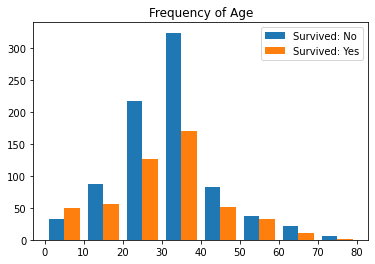

```python
# Age frequency
dt0 = df['age'][df['survived']==0]
dt1 = df['age'][df['survived']==1]

bins = np.arange(0, df['age'].max()+10, 10)

plt.hist([dt0,dt1], label=['Survived: No','Survived: Yes'], bins=bins)

plt.legend(loc='upper right')
plt.title('Frequency of Age');
```

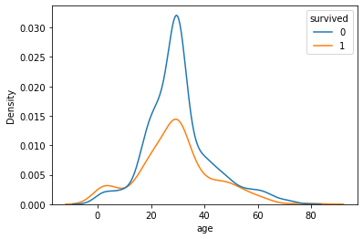

```python
sns.kdeplot(data=df, x="age", hue="survived", fill=False);
```

```python
# we could create bins to break age into categories - child (0-8), teen(9-18), adult(19-54), aged(55+)
```

```python
df['age_group'] = pd.cut(df['age'], bins=[0,9,19,55,100], labels=["Child","Teen","Adult", "Aged"])
```

```python
df.head(30)
```

|  | pclass | survived | name | sex | age | sibsp | parch | fare | embarked | age_group |
| --- | --- | --- | --- | --- | --- | --- | --- | --- | --- | --- |
| 0 | 1 | 1 | Allen, Miss. Elisabeth Walton | female | 29.00 | 0 | 0 | 211.3375 | 2 | Adult |
| 1 | 1 | 1 | Allison, Master. Hudson Trevor | male | 0.92 | 1 | 2 | 151.5500 | 2 | Child |
| 3 | 1 | 0 | Allison, Miss. Helen Loraine | female | 2.00 | 1 | 2 | 151.5500 | 2 | Child |
| 4 | 1 | 0 | Allison, Mr. Hudson Joshua Creighton | male | 30.00 | 1 | 2 | 151.5500 | 2 | Adult |
| 5 | 1 | 0 | Allison, Mrs. Hudson J C (Bessie Waldo Daniels) | female | 25.00 | 1 | 2 | 151.5500 | 2 | Adult |
| 6 | 1 | 1 | Anderson, Mr. Harry | male | 48.00 | 0 | 0 | 26.5500 | 2 | Adult |
| 7 | 1 | 1 | Andrews, Miss. Kornelia Theodosia | female | 63.00 | 1 | 0 | 77.9583 | 2 | Aged |
| 8 | 1 | 0 | Andrews, Mr. Thomas Jr | male | 39.00 | 0 | 0 | 0.0000 | 2 | Adult |
| 9 | 1 | 1 | Appleton, Mrs. Edward Dale (Charlotte Lamson) | female | 53.00 | 2 | 0 | 51.4792 | 2 | Adult |
| 10 | 1 | 0 | Artagaveytia, Mr. Ramon | male | 71.00 | 0 | 0 | 49.5042 | 0 | Aged |
| 11 | 1 | 0 | Astor, Col. John Jacob | male | 47.00 | 1 | 0 | 227.5250 | 0 | Adult |
| 12 | 1 | 1 | Astor, Mrs. John Jacob (Madeleine Talmadge Force) | female | 18.00 | 1 | 0 | 227.5250 | 0 | Teen |
| 13 | 1 | 1 | Aubart, Mme. Leontine Pauline | female | 24.00 | 0 | 0 | 69.3000 | 0 | Adult |
| 14 | 1 | 1 | Barber, Miss. Ellen "Nellie" | female | 26.00 | 0 | 0 | 78.8500 | 2 | Adult |
| 15 | 1 | 1 | Barkworth, Mr. Algernon Henry Wilson | male | 80.00 | 0 | 0 | 30.0000 | 2 | Aged |
| 16 | 1 | 0 | Baumann, Mr. John D | male | 30.00 | 0 | 0 | 25.9250 | 2 | Adult |
| 17 | 1 | 0 | Baxter, Mr. Quigg Edmond | male | 24.00 | 0 | 1 | 247.5208 | 0 | Adult |
| 18 | 1 | 1 | Baxter, Mrs. James (Helene DeLaudeniere Chaput) | female | 50.00 | 0 | 1 | 247.5208 | 0 | Adult |
| 19 | 1 | 1 | Bazzani, Miss. Albina | female | 32.00 | 0 | 0 | 76.2917 | 0 | Adult |
| 20 | 1 | 0 | Beattie, Mr. Thomson | male | 36.00 | 0 | 0 | 75.2417 | 0 | Adult |
| 21 | 1 | 1 | Beckwith, Mr. Richard Leonard | male | 37.00 | 1 | 1 | 52.5542 | 2 | Adult |
| 22 | 1 | 1 | Beckwith, Mrs. Richard Leonard (Sallie Monypeny) | female | 47.00 | 1 | 1 | 52.5542 | 2 | Adult |
| 23 | 1 | 1 | Behr, Mr. Karl Howell | male | 26.00 | 0 | 0 | 30.0000 | 0 | Adult |
| 24 | 1 | 1 | Bidois, Miss. Rosalie | female | 42.00 | 0 | 0 | 227.5250 | 0 | Adult |
| 25 | 1 | 1 | Bird, Miss. Ellen | female | 29.00 | 0 | 0 | 221.7792 | 2 | Adult |
| 26 | 1 | 0 | Birnbaum, Mr. Jakob | male | 25.00 | 0 | 0 | 26.0000 | 0 | Adult |
| 27 | 1 | 1 | Bishop, Mr. Dickinson H | male | 25.00 | 1 | 0 | 91.0792 | 0 | Adult |
| 28 | 1 | 1 | Bishop, Mrs. Dickinson H (Helen Walton) | female | 19.00 | 1 | 0 | 91.0792 | 0 | Teen |
| 29 | 1 | 1 | Bissette, Miss. Amelia | female | 35.00 | 0 | 0 | 135.6333 | 2 | Adult |
| 30 | 1 | 1 | Bjornstrom-Steffansson, Mr. Mauritz Hakan | male | 28.00 | 0 | 0 | 26.5500 | 2 | Adult |

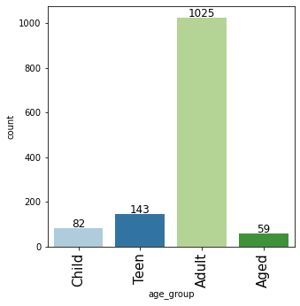

```python
labeled_barplot(df, 'age_group')
```

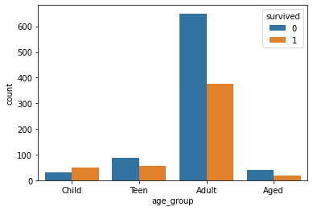

```python
sns.countplot(x='age_group', hue='survived', data=df)
```

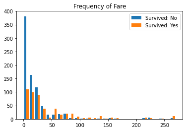

```python
# Fare frequency
dt0 = df['fare'][df['survived']==0]
dt1 = df['fare'][df['survived']==1]

bins = np.arange(0, df['fare'].max()+10, 10)

plt.hist([dt0,dt1], label=['Survived: No','Survived: Yes'], bins=bins)

plt.legend(loc='upper right')
plt.title('Frequency of Fare');
```

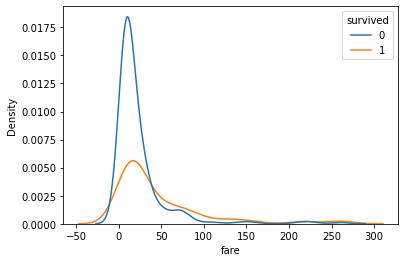

```python
sns.kdeplot(data=df, x="fare", hue="survived", fill=False);
```

```python
df.head(10)
```

|  | pclass | survived | name | sex | age | sibsp | parch | fare | embarked | age_group |
| --- | --- | --- | --- | --- | --- | --- | --- | --- | --- | --- |
| 0 | 1 | 1 | Allen, Miss. Elisabeth Walton | female | 29.00 | 0 | 0 | 211.3375 | 2 | Adult |
| 1 | 1 | 1 | Allison, Master. Hudson Trevor | male | 0.92 | 1 | 2 | 151.5500 | 2 | Child |
| 3 | 1 | 0 | Allison, Miss. Helen Loraine | female | 2.00 | 1 | 2 | 151.5500 | 2 | Child |
| 4 | 1 | 0 | Allison, Mr. Hudson Joshua Creighton | male | 30.00 | 1 | 2 | 151.5500 | 2 | Adult |
| 5 | 1 | 0 | Allison, Mrs. Hudson J C (Bessie Waldo Daniels) | female | 25.00 | 1 | 2 | 151.5500 | 2 | Adult |
| 6 | 1 | 1 | Anderson, Mr. Harry | male | 48.00 | 0 | 0 | 26.5500 | 2 | Adult |
| 7 | 1 | 1 | Andrews, Miss. Kornelia Theodosia | female | 63.00 | 1 | 0 | 77.9583 | 2 | Aged |
| 8 | 1 | 0 | Andrews, Mr. Thomas Jr | male | 39.00 | 0 | 0 | 0.0000 | 2 | Adult |
| 9 | 1 | 1 | Appleton, Mrs. Edward Dale (Charlotte Lamson) | female | 53.00 | 2 | 0 | 51.4792 | 2 | Adult |
| 10 | 1 | 0 | Artagaveytia, Mr. Ramon | male | 71.00 | 0 | 0 | 49.5042 | 0 | Aged |

```python
# fare_type - Complimentary = 0, Low 1-49, High 50+
df['fare_type'] = pd.cut(df['fare'], bins=[-10,0,50,300], labels=["Complimentary","Low","High"])
```

```python
df.head(10)
```

|  | pclass | survived | name | sex | age | sibsp | parch | fare | embarked | age_group | fare_type |
| --- | --- | --- | --- | --- | --- | --- | --- | --- | --- | --- | --- |
| 0 | 1 | 1 | Allen, Miss. Elisabeth Walton | female | 29.00 | 0 | 0 | 211.3375 | 2 | Adult | High |
| 1 | 1 | 1 | Allison, Master. Hudson Trevor | male | 0.92 | 1 | 2 | 151.5500 | 2 | Child | High |
| 3 | 1 | 0 | Allison, Miss. Helen Loraine | female | 2.00 | 1 | 2 | 151.5500 | 2 | Child | High |
| 4 | 1 | 0 | Allison, Mr. Hudson Joshua Creighton | male | 30.00 | 1 | 2 | 151.5500 | 2 | Adult | High |
| 5 | 1 | 0 | Allison, Mrs. Hudson J C (Bessie Waldo Daniels) | female | 25.00 | 1 | 2 | 151.5500 | 2 | Adult | High |
| 6 | 1 | 1 | Anderson, Mr. Harry | male | 48.00 | 0 | 0 | 26.5500 | 2 | Adult | Low |
| 7 | 1 | 1 | Andrews, Miss. Kornelia Theodosia | female | 63.00 | 1 | 0 | 77.9583 | 2 | Aged | High |
| 8 | 1 | 0 | Andrews, Mr. Thomas Jr | male | 39.00 | 0 | 0 | 0.0000 | 2 | Adult | Complimentary |
| 9 | 1 | 1 | Appleton, Mrs. Edward Dale (Charlotte Lamson) | female | 53.00 | 2 | 0 | 51.4792 | 2 | Adult | High |
| 10 | 1 | 0 | Artagaveytia, Mr. Ramon | male | 71.00 | 0 | 0 | 49.5042 | 0 | Aged | Low |

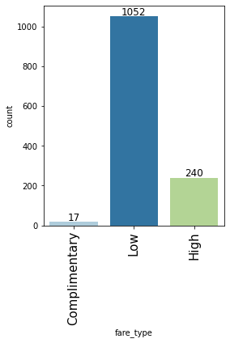

```python
labeled_barplot(df, 'fare_type')
```

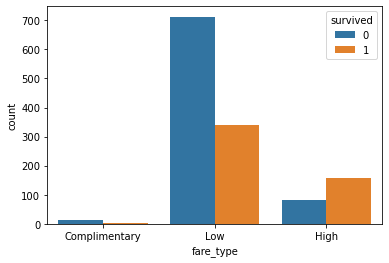

```python
sns.countplot(x='fare_type', hue='survived', data=df)
```

```python
pd.crosstab(df['survived'],df['fare_type'])
```

| fare_type survived | Complimentary | Low | High |
| --- | --- | --- | --- |
| 0 | 15 | 712 | 82 |
| 1 | 2 | 340 | 158 |

```python
# Complimentary - 12% survived
# Low - 32% survived
# High - 66% survived
```

### Feature Extraction

```python
df.name.unique()
```

```
array(['Allen, Miss. Elisabeth Walton', 'Allison, Master. Hudson Trevor',
       'Allison, Miss. Helen Loraine', ..., 'Zakarian, Mr. Mapriededer',
       'Zakarian, Mr. Ortin', 'Zimmerman, Mr. Leo'], dtype=object)
```

```python
# lastname, title. Firstname Maidenname/Middlename
```

```python
df['last_name'] = df.name.str.extract('([A-Za-z]+)')
df['title'] = df.name.str.extract('([A-Za-z]+)\.')
```

```python
df.head()
```

|  | pclass | survived | name | sex | age | sibsp | parch | fare | embarked | age_group | fare_type | last_name | title |
| --- | --- | --- | --- | --- | --- | --- | --- | --- | --- | --- | --- | --- | --- |
| 0 | 1 | 1 | Allen, Miss. Elisabeth Walton | female | 29.00 | 0 | 0 | 211.3375 | 2 | Adult | High | Allen | Miss |
| 1 | 1 | 1 | Allison, Master. Hudson Trevor | male | 0.92 | 1 | 2 | 151.5500 | 2 | Child | High | Allison | Master |
| 3 | 1 | 0 | Allison, Miss. Helen Loraine | female | 2.00 | 1 | 2 | 151.5500 | 2 | Child | High | Allison | Miss |
| 4 | 1 | 0 | Allison, Mr. Hudson Joshua Creighton | male | 30.00 | 1 | 2 | 151.5500 | 2 | Adult | High | Allison | Mr |
| 5 | 1 | 0 | Allison, Mrs. Hudson J C (Bessie Waldo Daniels) | female | 25.00 | 1 | 2 | 151.5500 | 2 | Adult | High | Allison | Mrs |

```python
df.groupby('last_name')['name'].nunique()
```

```
last_name
Abbing         1
Abbott         3
Abelseth       2
Abelson        2
Abrahamsson    1
              ..
Zakarian       2
Zimmerman      1
de             5
del            2
van            4
Name: name, Length: 853, dtype: int64
```

```python
df.title.value_counts()
```

```
Mr          757
Miss        260
Mrs         197
Master       61
Rev           8
Dr            8
Col           4
Mlle          2
Ms            2
Major         2
Capt          1
Sir           1
Dona          1
Jonkheer      1
Countess      1
Don           1
Mme           1
Lady          1
Name: title, dtype: int64
```

```python
# Needs some cleanup
df.loc[df['title'] == 'Mlle', ['title']] = 'Ms'
df.loc[df['title'] == 'Mme', ['title']] = 'Mrs'
df.loc[df['title'] == 'Miss', ['title']] = 'Ms'
df.loc[df['title'] == 'Lady', ['title']] = 'Royalty'
df.loc[df['title'] == 'Sir', ['title']] = 'Royalty'
df.loc[df['title'] == 'Dona', ['title']] = 'Royalty'
df.loc[df['title'] == 'Countess', ['title']] = 'Royalty'
df.loc[df['title'] == 'Don', ['title']] = 'Royalty'
df.loc[df['title'] == 'Jonkheer', ['title']] = 'Royalty'
df.loc[df['title'] == 'Dr', ['title']] = 'Officer'
df.loc[df['title'] == 'Rev', ['title']] = 'Officer'
df.loc[df['title'] == 'Col', ['title']] = 'Officer'
df.loc[df['title'] == 'Major', ['title']] = 'Officer'
df.loc[df['title'] == 'Capt', ['title']] = 'Officer'
```

```python
df.title.value_counts()
```

```
Mr         757
Ms         264
Mrs        198
Master      61
Officer     23
Royalty      6
Name: title, dtype: int64
```

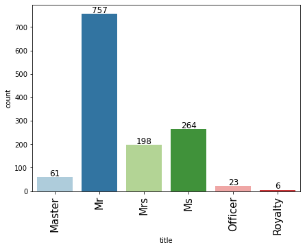

```python
labeled_barplot(df, 'title')
```

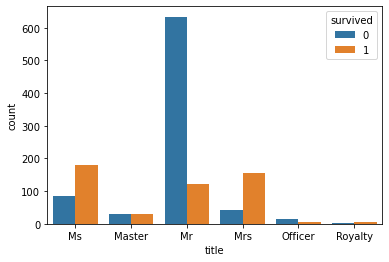

```python
sns.countplot(x='title', hue='survived', data=df)
```

```python
pd.crosstab(df['survived'],df['title'])
```

| title survived | Master | Mr | Mrs | Ms | Officer | Royalty |
| --- | --- | --- | --- | --- | --- | --- |
| 0 | 30 | 634 | 42 | 85 | 16 | 2 |
| 1 | 31 | 123 | 156 | 179 | 7 | 4 |

```python
# Master - 51% survived
# Mr - 16% survived
# Mrs - 79% survived
# Ms - 68% survived
# Officer - 30% survived
# Royalty - 67% survived
```

```python
# family size
df['family_size'] = df['sibsp'] + df['parch'] + 1
```

```python
df.head()
```

|  | pclass | survived | name | sex | age | sibsp | parch | fare | embarked | age_group | fare_type | last_name | title | family_size |
| --- | --- | --- | --- | --- | --- | --- | --- | --- | --- | --- | --- | --- | --- | --- |
| 0 | 1 | 1 | Allen, Miss. Elisabeth Walton | female | 29.00 | 0 | 0 | 211.3375 | 2 | Adult | High | Allen | Ms | 1 |
| 1 | 1 | 1 | Allison, Master. Hudson Trevor | male | 0.92 | 1 | 2 | 151.5500 | 2 | Child | High | Allison | Master | 4 |
| 3 | 1 | 0 | Allison, Miss. Helen Loraine | female | 2.00 | 1 | 2 | 151.5500 | 2 | Child | High | Allison | Ms | 4 |
| 4 | 1 | 0 | Allison, Mr. Hudson Joshua Creighton | male | 30.00 | 1 | 2 | 151.5500 | 2 | Adult | High | Allison | Mr | 4 |
| 5 | 1 | 0 | Allison, Mrs. Hudson J C (Bessie Waldo Daniels) | female | 25.00 | 1 | 2 | 151.5500 | 2 | Adult | High | Allison | Mrs | 4 |

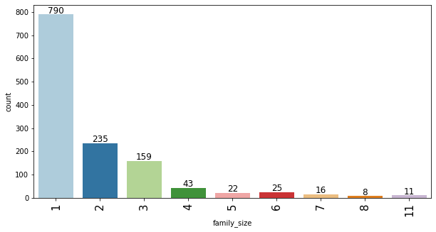

```python
labeled_barplot(df, 'family_size')
```

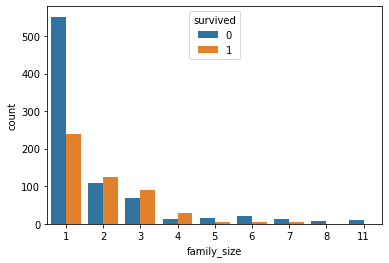

```python
sns.countplot(x='family_size', hue='survived', data=df)
```

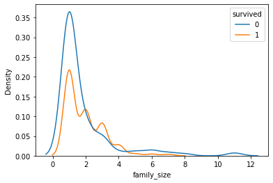

```python
sns.kdeplot(data=df, x="family_size", hue="survived", fill=False);
```

```python
# possibly group family_size -> alone, small (2 - 4), large (5+)
```

```python
df['alone'] = df.family_size == 1
```

```python
df.head()
```

|  | pclass | survived | name | sex | age | sibsp | parch | fare | embarked | age_group | fare_type | last_name | title | family_size | alone |
| --- | --- | --- | --- | --- | --- | --- | --- | --- | --- | --- | --- | --- | --- | --- | --- |
| 0 | 1 | 1 | Allen, Miss. Elisabeth Walton | female | 29.00 | 0 | 0 | 211.3375 | 2 | Adult | High | Allen | Ms | 1 | True |
| 1 | 1 | 1 | Allison, Master. Hudson Trevor | male | 0.92 | 1 | 2 | 151.5500 | 2 | Child | High | Allison | Master | 4 | False |
| 3 | 1 | 0 | Allison, Miss. Helen Loraine | female | 2.00 | 1 | 2 | 151.5500 | 2 | Child | High | Allison | Ms | 4 | False |
| 4 | 1 | 0 | Allison, Mr. Hudson Joshua Creighton | male | 30.00 | 1 | 2 | 151.5500 | 2 | Adult | High | Allison | Mr | 4 | False |
| 5 | 1 | 0 | Allison, Mrs. Hudson J C (Bessie Waldo Daniels) | female | 25.00 | 1 | 2 | 151.5500 | 2 | Adult | High | Allison | Mrs | 4 | False |

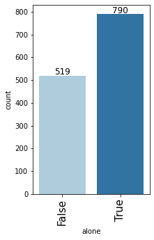

```python
labeled_barplot(df, 'alone')
```

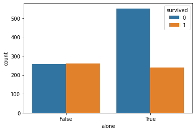

```python
sns.countplot(x='alone', hue='survived', data=df)
```

#### Log Transformation

```python
df = data.copy()
```

```python
df.fare.describe()
```

```
count    1309.000000
mean       31.898873
std        44.448381
min         0.000000
25%         7.895800
50%        14.454200
75%        31.275000
max       263.000000
Name: fare, dtype: float64
```

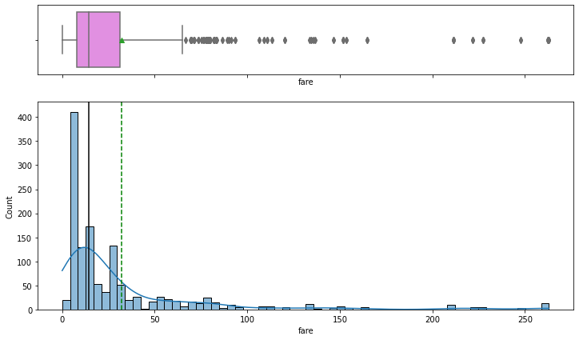

```python
histogram_boxplot(df, 'fare',kde=True)
```

```python
df['fare'] = df['fare'] + 0.01
```

```python
df.fare.describe()
```

```
count    1309.000000
mean       31.908873
std        44.448381
min         0.010000
25%         7.905800
50%        14.464200
75%        31.285000
max       263.010000
Name: fare, dtype: float64
```

```python
df['fare'] = np.log(df['fare'])
```

```python
df.fare.describe()
```

```
count    1309.000000
mean        2.844770
std         1.263779
min        -4.605170
25%         2.067597
50%         2.671677
75%         3.443139
max         5.572192
Name: fare, dtype: float64
```

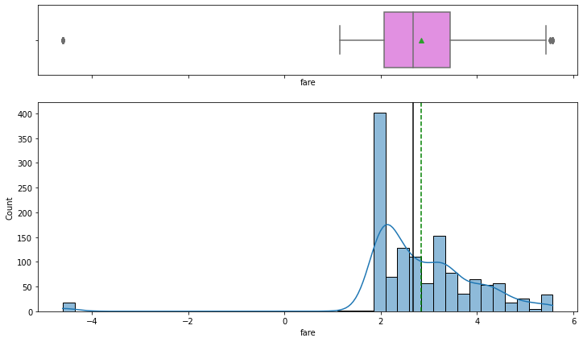

```python
histogram_boxplot(df, 'fare',kde=True)
```

#### Things to consider

- name
- sex vs title
- age vs age_group
- sibsp/parch vs family_size/alone
- fare vs fare_type